# Feature Importance GxE

Ty Thomas

2026-07-08

## Read Data

The code below reads the data in.

```r
# Read in Data
sv <- read_tsv("../data/sv_per_gene.tsv") |> select(-is_bg, -strand)
dap <- read_tsv("../data/dap_seq_per_gene.tsv") |> select(-gene_class, -is_bg, -prom_s, -prom_e, -strand) |> mutate(across(everything(), ~ replace_na(.x, 0)))


# Combine the two together and order the columns
sv_dap <- left_join(sv, dap, by=c("gene", "chr", "is_gxe")) |> select(-gene, -chr) |>
  mutate(n_sv_total = n_sv_total, .before = n_small_indel)

dap1 <- dap |> select(-gene, -chr)

sv1 <- sv |> select(-gene, -chr)

# Make all characters factors
sv_dap_clean <- sv_dap |>
  mutate(
    is_gxe = as.factor(is_gxe),
    across(where(is.character) | where(is.logical), as.factor)
  )
```

## Stats reference

### Modeling and Statistical Metrics Reference Guide

This reference table outlines the different modeling frameworks, the statistical metrics used to evaluate feature importance and standalone predictive power, and how to interpret their values.

Summary of Modeling Methods and Feature Importance Metrics

[output not shown]

## Base Data Models

### Structural Variants

TL;DR:

- Between all 4 models, the each variable shows importance at least once.
- `n_small_indel` is consistently strong agross all 4 models.
- Model roc_auc between 0.56 and 0.60

```r
SV_Models_All<- run_all_mods(sv1, Group_title = "Structural Variants")
```

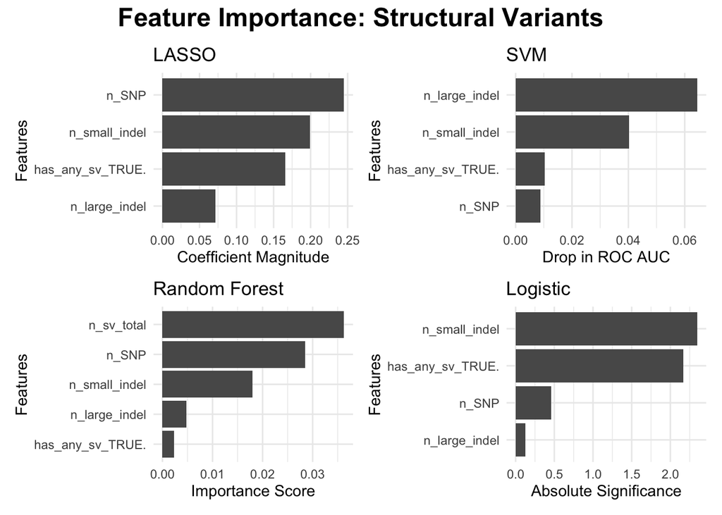

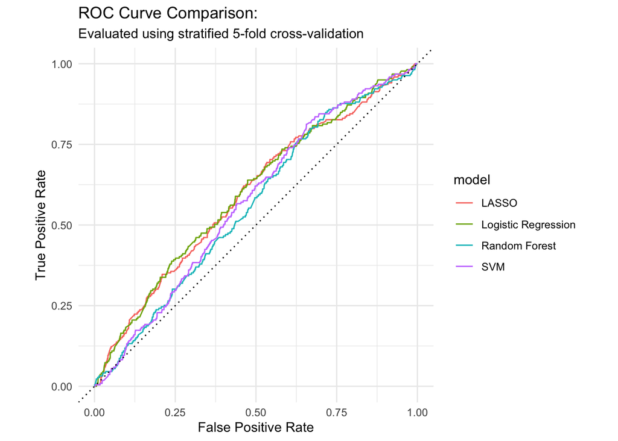

Comparative ROC AUC Performance:

| Model | Metric | Estimate |
| --- | --- | --- |
| LASSO | roc_auc | 0.5947 |
| Logistic Regression | roc_auc | 0.6004 |
| Random Forest | roc_auc | 0.5602 |
| SVM | roc_auc | 0.5727 |

Logistic: Structural Variants

| Term (Variable) | Estimate (Slope) | Std. Error | z-statistic | p-value |
| --- | --- | --- | --- | --- |
| (Intercept) | -3.7488 | 0.2454 | -15.2779 | < 0.0001 |
| n_small_indel | 0.0707 | 0.0191 | 3.6936 | 2e-04 |
| n_large_indel | 0.1473 | 0.0882 | 1.6698 | 0.095 |
| n_SNP | -0.0067 | 0.0047 | -1.4196 | 0.1557 |
| n_sv_total | NA | NA | NA | NA |
| has_any_svTRUE | -0.5404 | 0.2678 | -2.0181 | 0.0436 |

### DAP_seq

TL;DR:

```r
DAP_Models_All<- run_all_mods(dap1, Group_title = "Dap_seq")
```

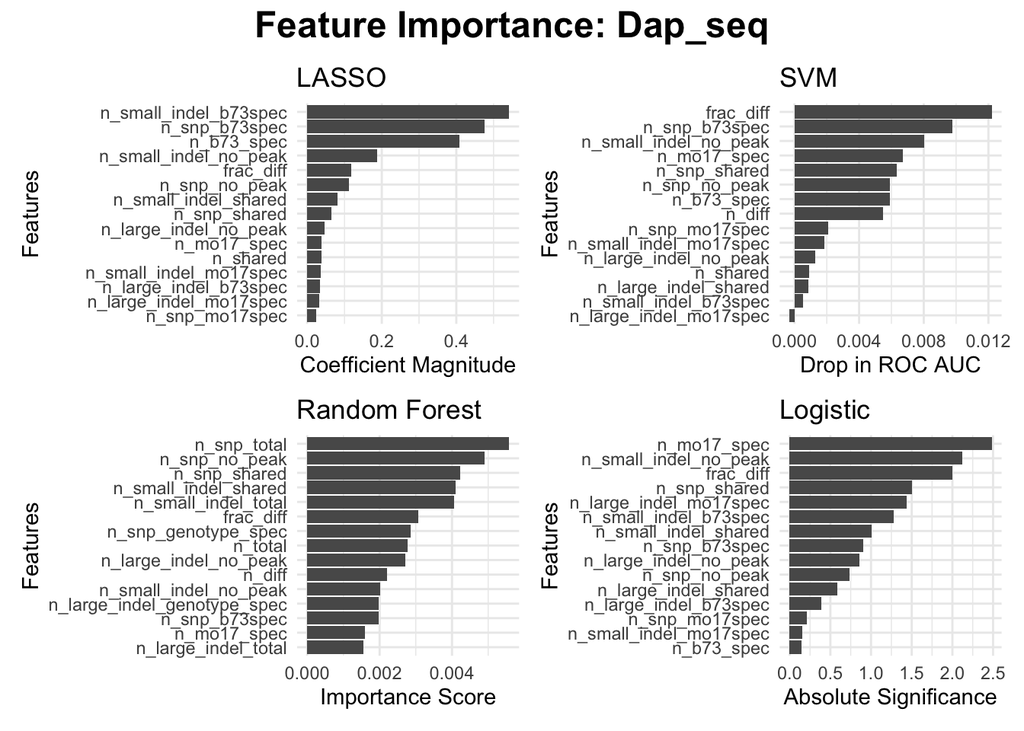

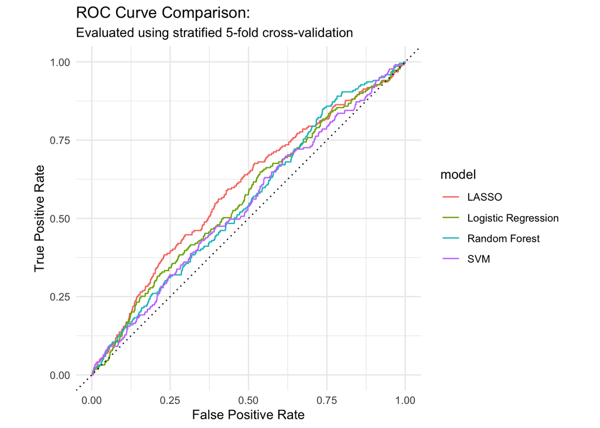

Comparative ROC AUC Performance:

| Model | Metric | Estimate |
| --- | --- | --- |
| LASSO | roc_auc | 0.5915 |
| Logistic Regression | roc_auc | 0.5625 |
| Random Forest | roc_auc | 0.5525 |
| SVM | roc_auc | 0.5423 |

Logistic: Dap_seq

| Term (Variable) | Estimate (Slope) | Std. Error | z-statistic | p-value |
| --- | --- | --- | --- | --- |
| (Intercept) | -4.2932 | 0.1290 | -33.2895 | < 0.0001 |
| n_b73_spec | 0.0236 | 0.0642 | 0.3677 | 0.7131 |
| n_shared | -0.0092 | 0.0228 | -0.4006 | 0.6887 |
| n_mo17_spec | -0.0937 | 0.1141 | -0.8208 | 0.4118 |
| n_diff | NA | NA | NA | NA |
| n_total | NA | NA | NA | NA |
| frac_diff | 0.5552 | 0.2440 | 2.2757 | 0.0229 |
| n_small_indel_b73spec | -0.0508 | 0.0430 | -1.1813 | 0.2375 |
| n_small_indel_mo17spec | -0.3253 | 0.2576 | -1.2627 | 0.2067 |
| n_small_indel_shared | 0.0105 | 0.0138 | 0.7606 | 0.4469 |
| n_small_indel_no_peak | 0.0768 | 0.0235 | 3.2700 | 0.0011 |
| n_small_indel_genotype_spec | NA | NA | NA | NA |
| n_small_indel_total | NA | NA | NA | NA |
| n_large_indel_b73spec | 0.0461 | 0.0910 | 0.5070 | 0.6122 |
| n_large_indel_mo17spec | 0.3724 | 0.1959 | 1.9008 | 0.0573 |
| n_large_indel_shared | 0.0629 | 0.0680 | 0.9249 | 0.355 |
| n_large_indel_no_peak | 0.0831 | 0.0978 | 0.8490 | 0.3959 |
| n_large_indel_genotype_spec | NA | NA | NA | NA |
| n_large_indel_total | NA | NA | NA | NA |
| n_snp_b73spec | 0.0108 | 0.0111 | 0.9779 | 0.3281 |
| n_snp_mo17spec | -0.0063 | 0.0379 | -0.1654 | 0.8686 |
| n_snp_shared | 0.0066 | 0.0063 | 1.0381 | 0.2992 |
| n_snp_no_peak | -0.0084 | 0.0066 | -1.2626 | 0.2067 |
| n_snp_genotype_spec | NA | NA | NA | NA |
| n_snp_total | NA | NA | NA | NA |

### Combined features

TL;DR:

```r
SV_DAP_Models_All<- run_all_mods(sv_dap, Group_title = "Combined Features")
```

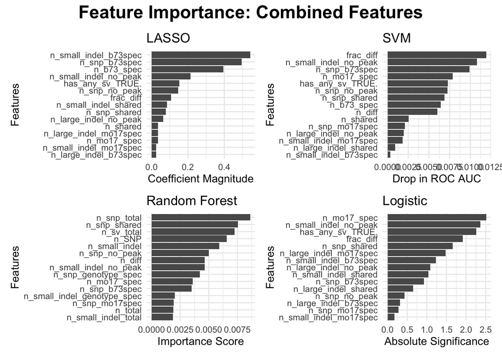

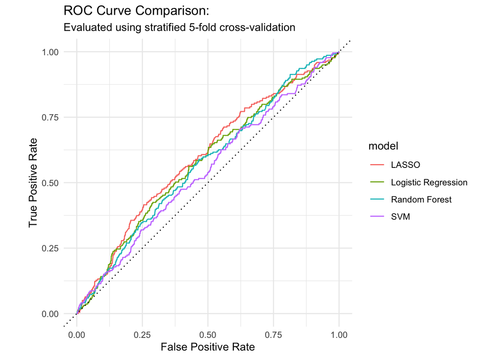

Comparative ROC AUC Performance:

| Model | Metric | Estimate |
| --- | --- | --- |
| LASSO | roc_auc | 0.5967 |
| Logistic Regression | roc_auc | 0.5774 |
| Random Forest | roc_auc | 0.5708 |
| SVM | roc_auc | 0.5438 |

Logistic: Combined Features

| Term (Variable) | Estimate (Slope) | Std. Error | z-statistic | p-value |
| --- | --- | --- | --- | --- |
| (Intercept) | -3.8039 | 0.2578 | -14.7531 | < 0.0001 |
| n_small_indel | 0.1281 | 0.0649 | 1.9730 | 0.0485 |
| n_large_indel | -0.3284 | 0.2886 | -1.1379 | 0.2552 |
| n_SNP | 0.0397 | 0.0217 | 1.8303 | 0.0672 |
| n_sv_total | NA | NA | NA | NA |
| has_any_svTRUE | -0.6663 | 0.2719 | -2.4502 | 0.0143 |
| n_b73_spec | 0.0501 | 0.0660 | 0.7599 | 0.4473 |
| n_shared | -0.0073 | 0.0231 | -0.3149 | 0.7528 |
| n_mo17_spec | -0.0814 | 0.1132 | -0.7186 | 0.4724 |
| n_diff | NA | NA | NA | NA |
| n_total | NA | NA | NA | NA |
| frac_diff | 0.5022 | 0.2592 | 1.9373 | 0.0527 |
| n_small_indel_b73spec | -0.1230 | 0.0578 | -2.1271 | 0.0334 |
| n_small_indel_mo17spec | -0.4277 | 0.2682 | -1.5947 | 0.1108 |
| n_small_indel_shared | -0.0082 | 0.0208 | -0.3940 | 0.6936 |
| n_small_indel_no_peak | -0.0523 | 0.0723 | -0.7233 | 0.4695 |
| n_small_indel_genotype_spec | NA | NA | NA | NA |
| n_small_indel_total | NA | NA | NA | NA |
| n_large_indel_b73spec | 0.1608 | 0.1202 | 1.3378 | 0.181 |
| n_large_indel_mo17spec | 0.4637 | 0.2044 | 2.2689 | 0.0233 |
| n_large_indel_shared | 0.1141 | 0.0761 | 1.4983 | 0.134 |
| n_large_indel_no_peak | 0.4520 | 0.3023 | 1.4954 | 0.1348 |
| n_large_indel_genotype_spec | NA | NA | NA | NA |
| n_large_indel_total | NA | NA | NA | NA |
| n_snp_b73spec | -0.0001 | 0.0154 | -0.0087 | 0.993 |
| n_snp_mo17spec | -0.0275 | 0.0428 | -0.6432 | 0.5201 |
| n_snp_shared | -0.0013 | 0.0086 | -0.1536 | 0.878 |
| n_snp_no_peak | -0.0484 | 0.0236 | -2.0529 | 0.0401 |
| n_snp_genotype_spec | NA | NA | NA | NA |
| n_snp_total | NA | NA | NA | NA |

## Individual Predictive Power

TL;DR:

- Looking at the first table, there are 9 factors with AUC > 0.550. 8 have mutual information score above 0. this is because `n_sv_total` and `n_SNP` are highly correlated.
- `n_small_indel` is the most predictive of `is_gxe`.
- When modeling using only the “best” features, the models don’t increase in accuracy.

```r
sv_dap_clean <- clean_dataset(sv_dap)
predictive_signals <- calculate_predictive_metrics(sv_dap_clean, "is_gxe")

pander::pander(predictive_signals, caption = "Standalone Predictive Capacity per Feature for is_gxe")
```

Standalone Predictive Capacity per Feature for is_gxe

| Variable | Source | Univariate_AUC | Mutual_Information |
| --- | --- | --- | --- |
| n_small_indel | SV Only | 0.5908 | 0.001 |
| n_sv_total | SV Only | 0.5833 | 0 |
| n_SNP | SV Only | 0.5756 | 2e-04 |
| n_snp_total | DAP Only | 0.5733 | 6e-04 |
| n_small_indel_no_peak | DAP Only | 0.5694 | 2e-04 |
| n_snp_shared | DAP Only | 0.558 | 4e-04 |
| n_small_indel_total | DAP Only | 0.5538 | 3e-04 |
| n_snp_no_peak | DAP Only | 0.5512 | 2e-04 |
| frac_diff | DAP Only | 0.5511 | 0.0011 |
| n_snp_genotype_spec | DAP Only | 0.545 | 1e-04 |
| n_small_indel_shared | DAP Only | 0.5436 | 5e-04 |
| n_diff | DAP Only | 0.5435 | 4e-04 |
| n_snp_b73spec | DAP Only | 0.5434 | 1e-04 |
| n_large_indel | SV Only | 0.5363 | 6e-04 |
| n_b73_spec | DAP Only | 0.5357 | 4e-04 |
| n_small_indel_b73spec | DAP Only | 0.5273 | 2e-04 |
| n_small_indel_genotype_spec | DAP Only | 0.5242 | 2e-04 |
| n_large_indel_no_peak | DAP Only | 0.5223 | 2e-04 |
| n_large_indel_total | DAP Only | 0.5212 | 6e-04 |
| n_total | DAP Only | 0.5212 | 3e-04 |
| n_large_indel_genotype_spec | DAP Only | 0.5203 | 1e-04 |
| n_mo17_spec | DAP Only | 0.5184 | 1e-04 |
| n_large_indel_b73spec | DAP Only | 0.5149 | 2e-04 |
| n_snp_mo17spec | DAP Only | 0.5075 | 1e-04 |
| n_large_indel_mo17spec | DAP Only | 0.507 | 3e-04 |
| has_any_sv | SV Only | 0.507 | 0 |
| n_large_indel_shared | DAP Only | 0.5058 | 6e-04 |
| n_shared | DAP Only | 0.5019 | 3e-04 |
| n_small_indel_mo17spec | DAP Only | 0.4992 | 1e-04 |

### Features with individual AUC > 0.550

```r
# selecting the best AUC features
best_AUC <- sv_dap |>
  select(is_gxe, n_small_indel, n_SNP, n_snp_total, n_small_indel_no_peak,  n_snp_shared , n_small_indel_total, n_snp_no_peak, frac_diff)

Best_AUC_Models<- run_all_mods(best_AUC, Group_title = "Individual AUC > 0.550")
```

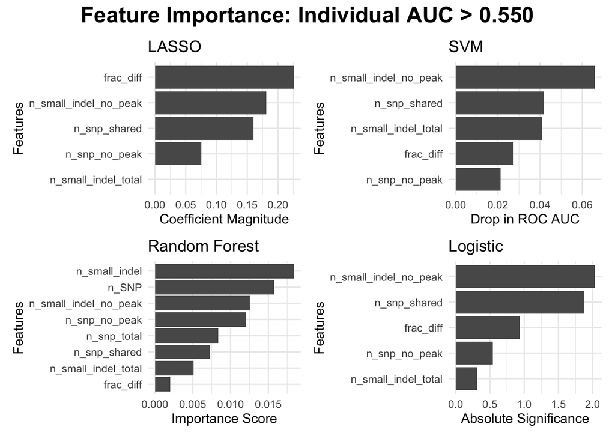

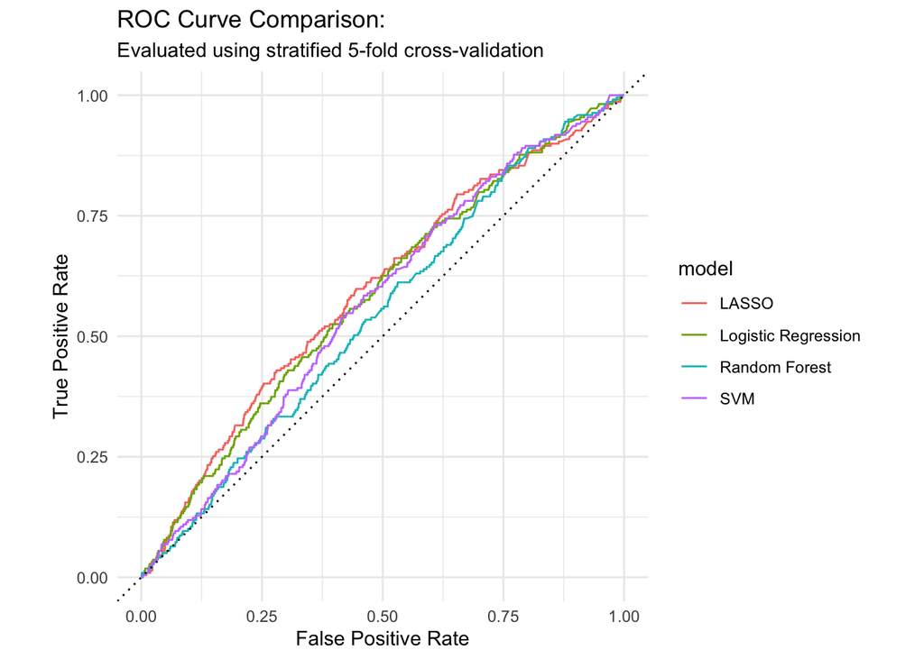

Comparative ROC AUC Performance:

| Model | Metric | Estimate |
| --- | --- | --- |
| LASSO | roc_auc | 0.5924 |
| Logistic Regression | roc_auc | 0.5825 |
| Random Forest | roc_auc | 0.5451 |
| SVM | roc_auc | 0.5672 |

Logistic: Individual AUC > 0.550

| Term (Variable) | Estimate (Slope) | Std. Error | z-statistic | p-value |
| --- | --- | --- | --- | --- |
| (Intercept) | -4.2960 | 0.1040 | -41.3072 | < 0.0001 |
| n_small_indel | 0.0871 | 0.0653 | 1.3333 | 0.1824 |
| n_SNP | 0.0348 | 0.0219 | 1.5928 | 0.1112 |
| n_snp_total | -0.0098 | 0.0135 | -0.7240 | 0.469 |
| n_small_indel_no_peak | -0.0196 | 0.0725 | -0.2704 | 0.7869 |
| n_snp_shared | 0.0105 | 0.0129 | 0.8079 | 0.4192 |
| n_small_indel_total | -0.0159 | 0.0217 | -0.7348 | 0.4625 |
| n_snp_no_peak | -0.0462 | 0.0236 | -1.9602 | 0.05 |
| frac_diff | 0.4000 | 0.2134 | 1.8746 | 0.0608 |

## Summarizing Features: Feature Totals vs Individuals

This Section separates out columns that are derived from the sums of other columns (totals), and columns that are not (individuals) to remove any strong correlations that may impact models.

```r
#separating fetures into totals and individuals
totals_cols<- c("n_large_indel_total" , "n_small_indel_total", "n_snp_total", "n_total", "n_diff", "n_small_indel_genotype_spec", "n_large_indel_genotype_spec", "n_snp_genotype_spec", "n_sv_total")

dap_T <- dap1 |>
  select(any_of(totals_cols), is_gxe)

dap_I <- dap1 |>
  select(-any_of(totals_cols))


sv_T <- sv1 |>
  select(any_of(totals_cols), is_gxe)

sv_I <- sv1 |>
  select(-any_of(totals_cols))


sv_dap_T <- sv_dap |>
  select(any_of(totals_cols), is_gxe)

sv_dap_I <- sv_dap |>
  select(-any_of(totals_cols))
```

### SV: Totals

```r
#SV_Models_T<- run_all_mods(sv_T, Group_title = "SV - Totals")
```

This model will not run as there is only one variable.

### SV: Individuals

```r
SV_Models_I<- run_all_mods(sv_I, Group_title = "SV - Individuals")
```

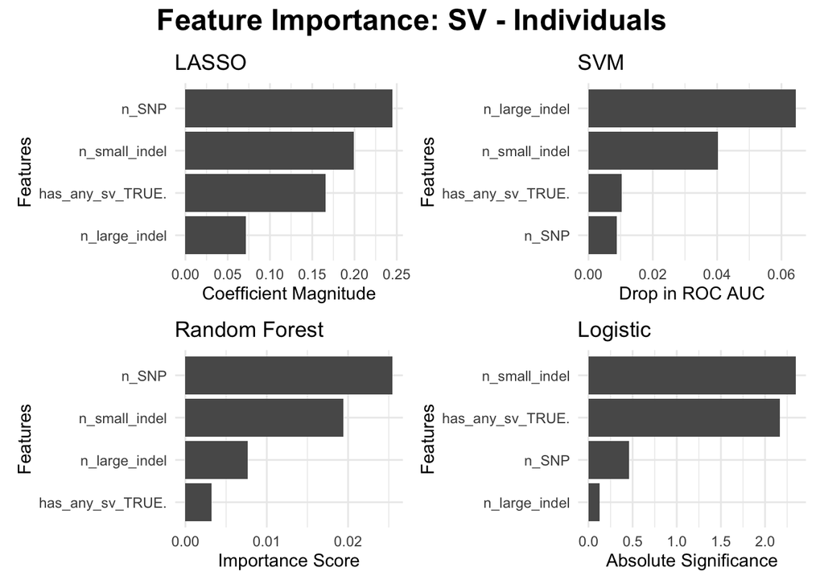

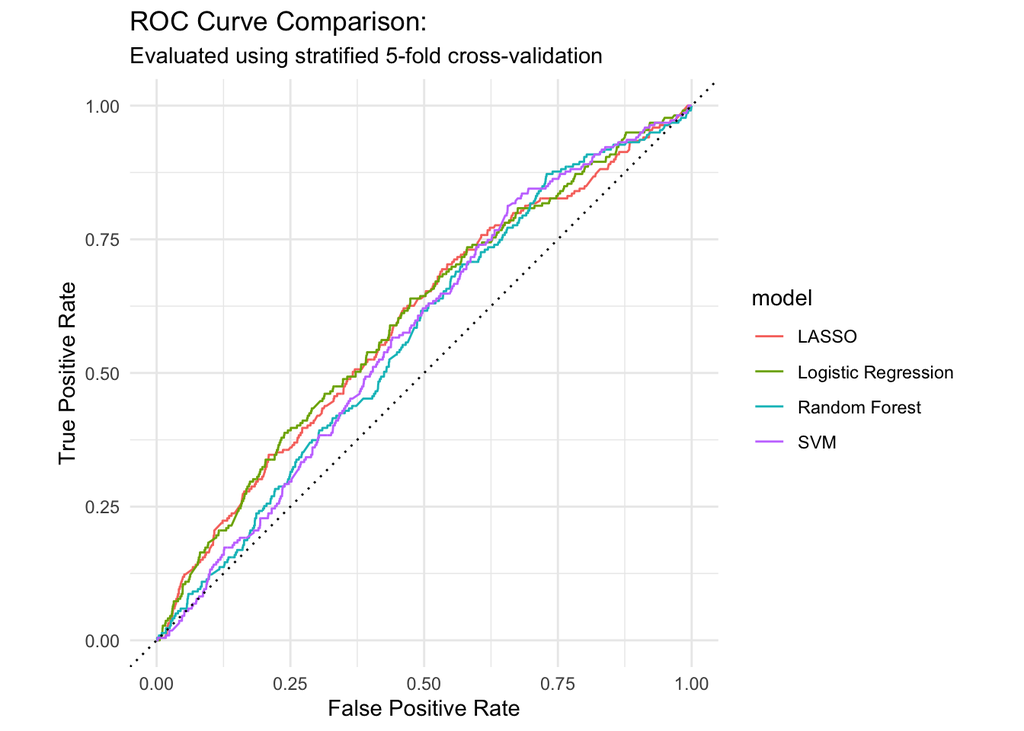

Comparative ROC AUC Performance:

| Model | Metric | Estimate |
| --- | --- | --- |
| LASSO | roc_auc | 0.5947 |
| Logistic Regression | roc_auc | 0.6004 |
| Random Forest | roc_auc | 0.5686 |
| SVM | roc_auc | 0.5727 |

Logistic: SV - Individuals

| Term (Variable) | Estimate (Slope) | Std. Error | z-statistic | p-value |
| --- | --- | --- | --- | --- |
| (Intercept) | -3.7488 | 0.2454 | -15.2779 | < 0.0001 |
| n_small_indel | 0.0707 | 0.0191 | 3.6936 | 2e-04 |
| n_large_indel | 0.1473 | 0.0882 | 1.6698 | 0.095 |
| n_SNP | -0.0067 | 0.0047 | -1.4196 | 0.1557 |
| has_any_svTRUE | -0.5404 | 0.2678 | -2.0181 | 0.0436 |

### DAP: Totals

- other than LASSO, `n_snp_total` is top two.
- `n_total` and `n_small_indel_total` are also of interest

```r
DAP_Models_T<- run_all_mods(dap_T, Group_title = "DAP - Totals")
```

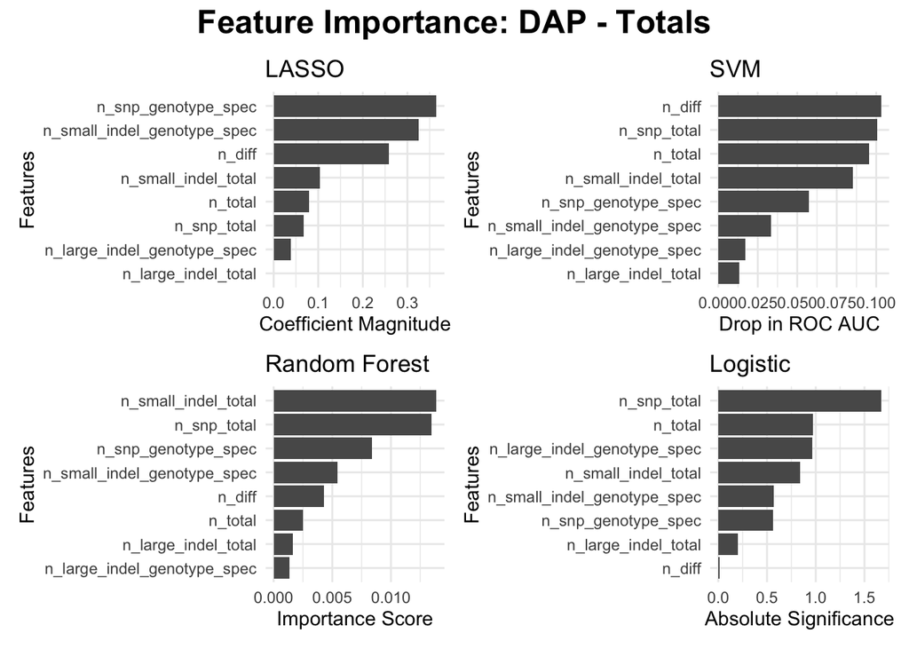

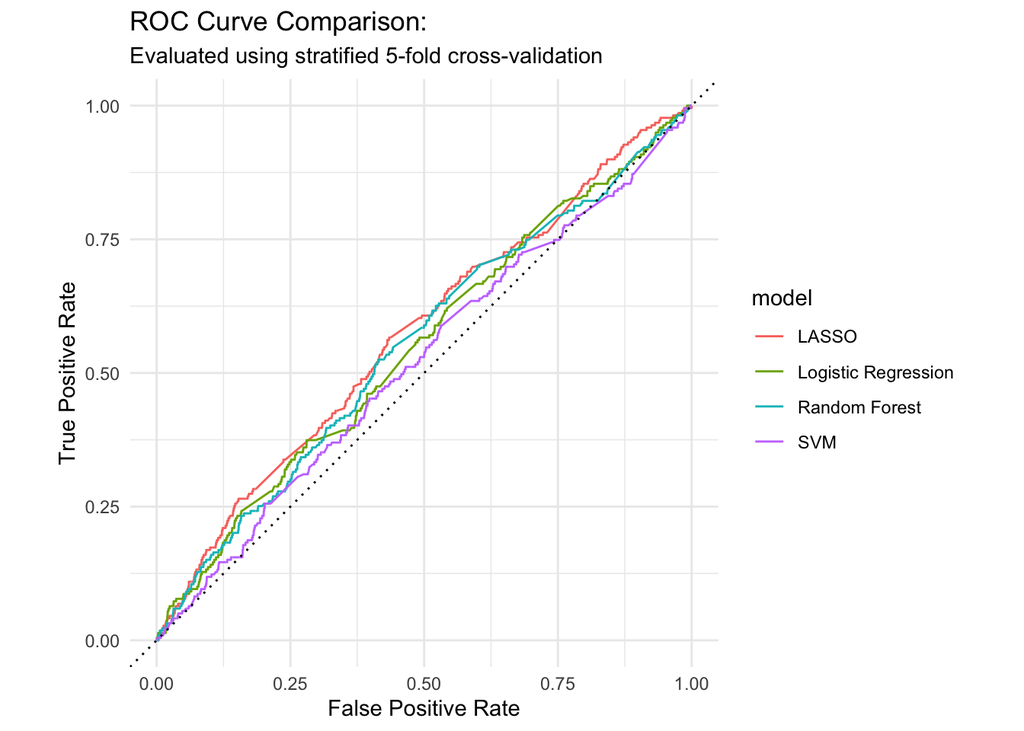

Comparative ROC AUC Performance:

| Model | Metric | Estimate |
| --- | --- | --- |
| LASSO | roc_auc | 0.5728 |
| Logistic Regression | roc_auc | 0.5496 |
| Random Forest | roc_auc | 0.5530 |
| SVM | roc_auc | 0.5210 |

Logistic: DAP - Totals

| Term (Variable) | Estimate (Slope) | Std. Error | z-statistic | p-value |
| --- | --- | --- | --- | --- |
| (Intercept) | -3.9629 | 0.0859 | -46.1404 | < 0.0001 |
| n_large_indel_total | 0.0527 | 0.0682 | 0.7721 | 0.4401 |
| n_small_indel_total | 0.0144 | 0.0134 | 1.0771 | 0.2814 |
| n_snp_total | 0.0076 | 0.0063 | 1.2037 | 0.2287 |
| n_total | -0.0363 | 0.0226 | -1.6061 | 0.1083 |
| n_diff | 0.0779 | 0.0515 | 1.5120 | 0.1305 |
| n_small_indel_genotype_spec | -0.0604 | 0.0443 | -1.3612 | 0.1735 |
| n_large_indel_genotype_spec | 0.0458 | 0.1128 | 0.4057 | 0.685 |
| n_snp_genotype_spec | 0.0004 | 0.0129 | 0.0323 | 0.9742 |

### DAP: Individuals

- `n_small_indel_no_peak` and `frac_diff` are interesting

```r
DAP_Models_I<- run_all_mods(dap_I, Group_title = "DAP - Individuals")
```

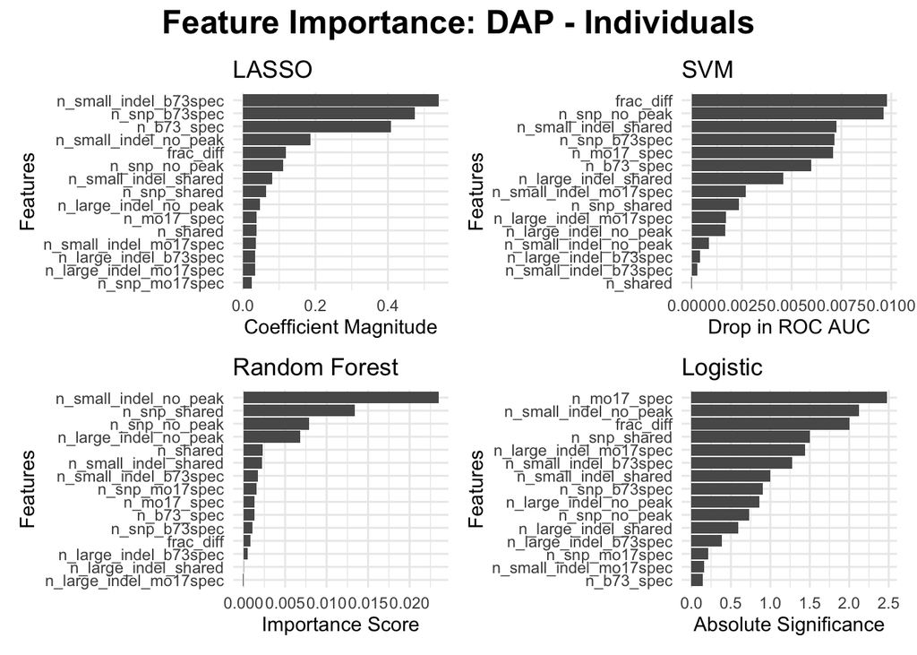

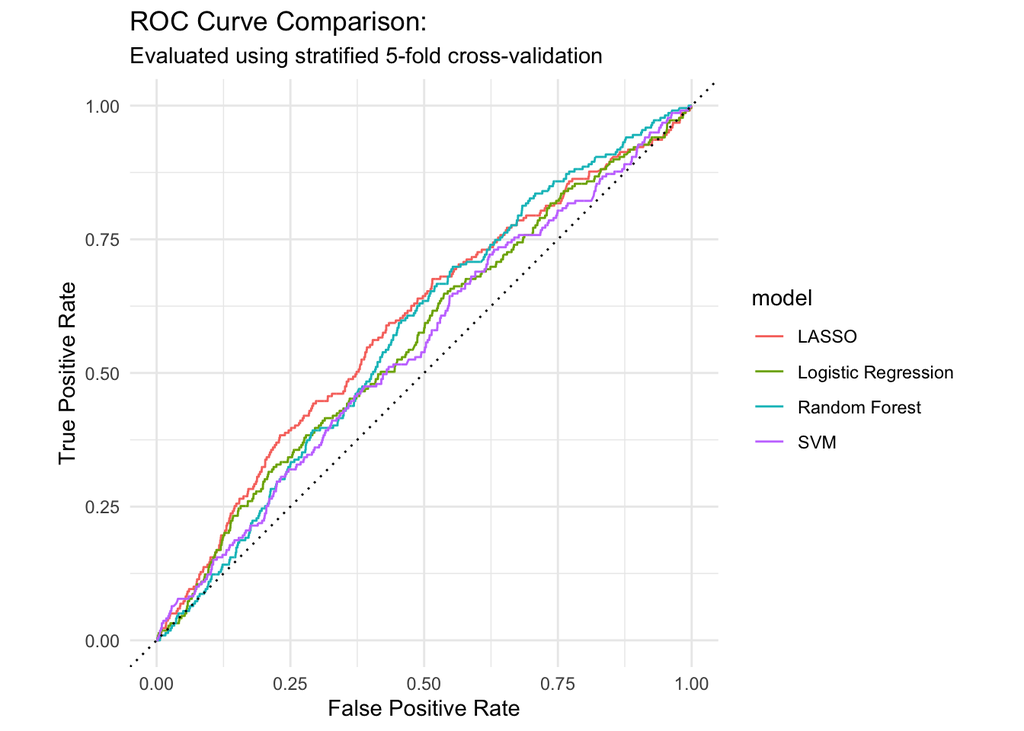

Comparative ROC AUC Performance:

| Model | Metric | Estimate |
| --- | --- | --- |
| LASSO | roc_auc | 0.5912 |
| Logistic Regression | roc_auc | 0.5625 |
| Random Forest | roc_auc | 0.5744 |
| SVM | roc_auc | 0.5494 |

Logistic: DAP - Individuals

| Term (Variable) | Estimate (Slope) | Std. Error | z-statistic | p-value |
| --- | --- | --- | --- | --- |
| (Intercept) | -4.2932 | 0.1290 | -33.2895 | < 0.0001 |
| n_b73_spec | 0.0236 | 0.0642 | 0.3677 | 0.7131 |
| n_shared | -0.0092 | 0.0228 | -0.4006 | 0.6887 |
| n_mo17_spec | -0.0937 | 0.1141 | -0.8208 | 0.4118 |
| frac_diff | 0.5552 | 0.2440 | 2.2757 | 0.0229 |
| n_small_indel_b73spec | -0.0508 | 0.0430 | -1.1813 | 0.2375 |
| n_small_indel_mo17spec | -0.3253 | 0.2576 | -1.2627 | 0.2067 |
| n_small_indel_shared | 0.0105 | 0.0138 | 0.7606 | 0.4469 |
| n_small_indel_no_peak | 0.0768 | 0.0235 | 3.2700 | 0.0011 |
| n_large_indel_b73spec | 0.0461 | 0.0910 | 0.5070 | 0.6122 |
| n_large_indel_mo17spec | 0.3724 | 0.1959 | 1.9008 | 0.0573 |
| n_large_indel_shared | 0.0629 | 0.0680 | 0.9249 | 0.355 |
| n_large_indel_no_peak | 0.0831 | 0.0978 | 0.8490 | 0.3959 |
| n_snp_b73spec | 0.0108 | 0.0111 | 0.9779 | 0.3281 |
| n_snp_mo17spec | -0.0063 | 0.0379 | -0.1654 | 0.8686 |
| n_snp_shared | 0.0066 | 0.0063 | 1.0381 | 0.2992 |
| n_snp_no_peak | -0.0084 | 0.0066 | -1.2626 | 0.2067 |

### Combined: Totals

```r
SV_DAP_Models_T<- run_all_mods(sv_dap_T, Group_title = "comb - Totals")
```

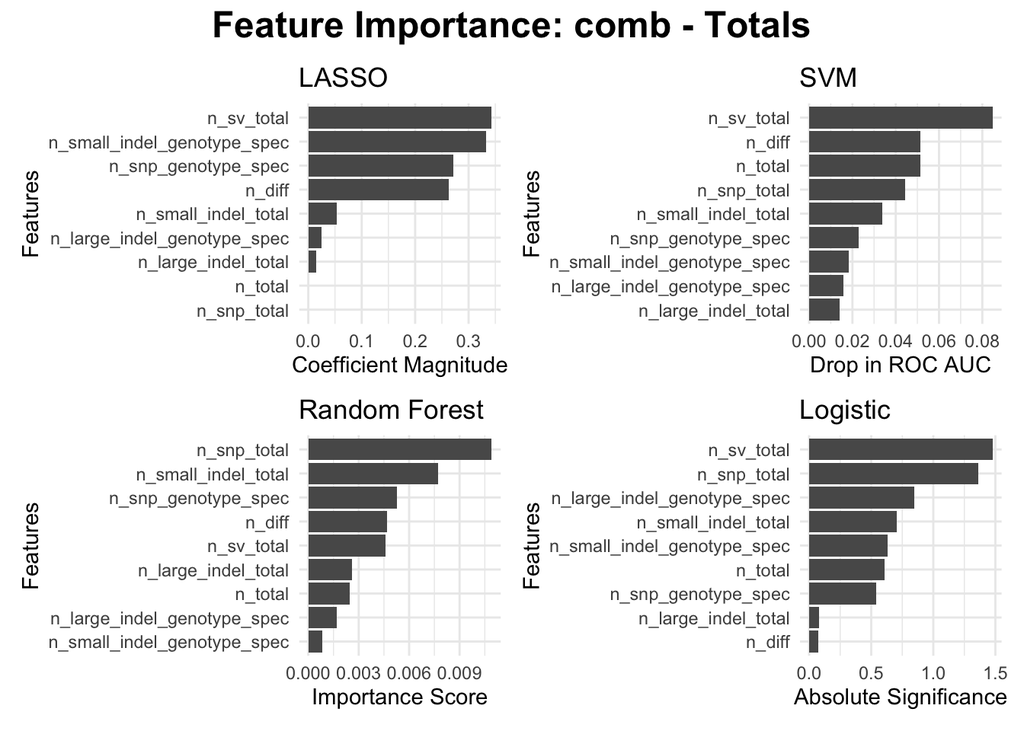

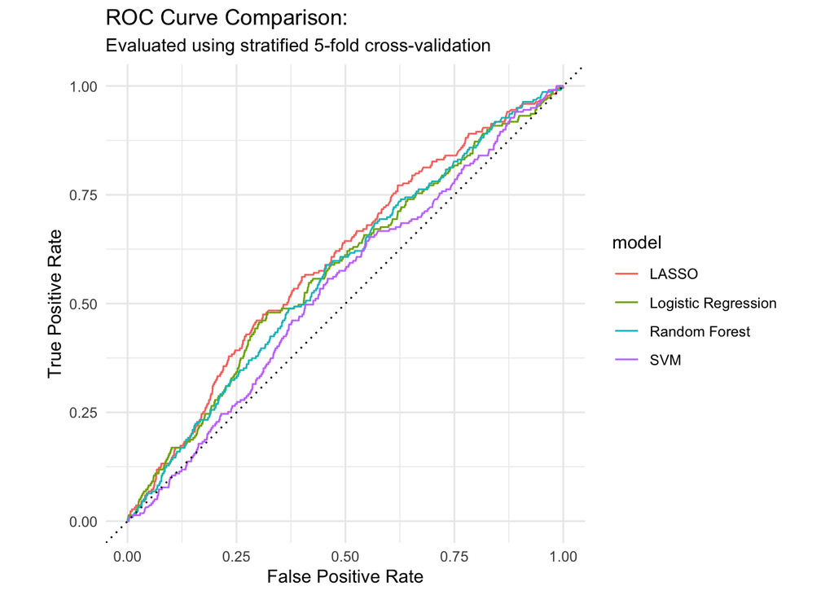

Comparative ROC AUC Performance:

| Model | Metric | Estimate |
| --- | --- | --- |
| LASSO | roc_auc | 0.5977 |
| Logistic Regression | roc_auc | 0.5749 |
| Random Forest | roc_auc | 0.5712 |
| SVM | roc_auc | 0.5364 |

Logistic: comb - Totals

| Term (Variable) | Estimate (Slope) | Std. Error | z-statistic | p-value |
| --- | --- | --- | --- | --- |
| (Intercept) | -4.0900 | 0.1005 | -40.6891 | < 0.0001 |
| n_large_indel_total | 0.0491 | 0.0687 | 0.7144 | 0.475 |
| n_small_indel_total | 0.0130 | 0.0137 | 0.9516 | 0.3413 |
| n_snp_total | 0.0058 | 0.0065 | 0.8888 | 0.3741 |
| n_total | -0.0293 | 0.0225 | -1.2981 | 0.1942 |
| n_diff | 0.0758 | 0.0517 | 1.4666 | 0.1425 |
| n_small_indel_genotype_spec | -0.0664 | 0.0458 | -1.4508 | 0.1468 |
| n_large_indel_genotype_spec | 0.0678 | 0.1150 | 0.5896 | 0.5554 |
| n_snp_genotype_spec | -0.0007 | 0.0134 | -0.0534 | 0.9574 |
| n_sv_total | 0.0061 | 0.0023 | 2.5928 | 0.0095 |

### Combined: Individuals

`n_small_indel_no_peak`

```r
SV_DAP_Models_I<- run_all_mods(sv_dap_I, Group_title = "comb - Individuals")
```

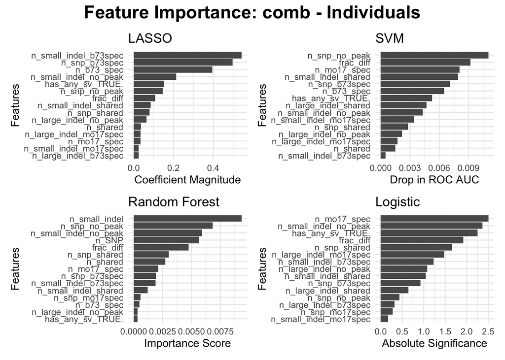

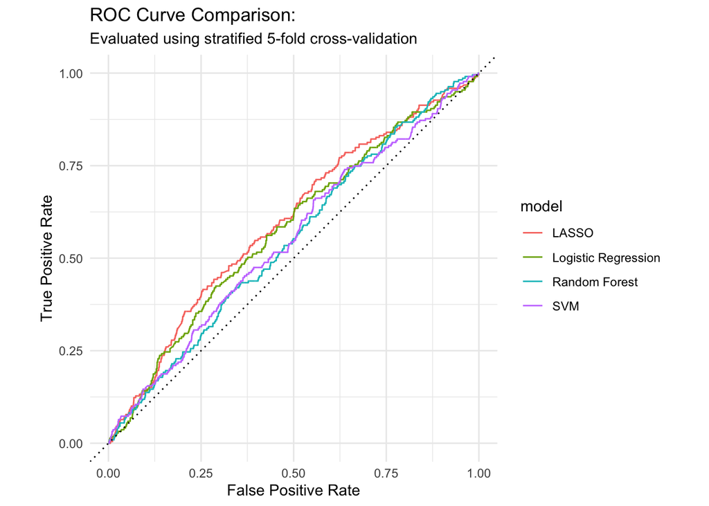

Comparative ROC AUC Performance:

| Model | Metric | Estimate |
| --- | --- | --- |
| LASSO | roc_auc | 0.5968 |
| Logistic Regression | roc_auc | 0.5774 |
| Random Forest | roc_auc | 0.5486 |
| SVM | roc_auc | 0.5503 |

Logistic: comb - Individuals

| Term (Variable) | Estimate (Slope) | Std. Error | z-statistic | p-value |
| --- | --- | --- | --- | --- |
| (Intercept) | -3.8039 | 0.2578 | -14.7531 | < 0.0001 |
| n_small_indel | 0.1281 | 0.0649 | 1.9730 | 0.0485 |
| n_large_indel | -0.3284 | 0.2886 | -1.1379 | 0.2552 |
| n_SNP | 0.0397 | 0.0217 | 1.8303 | 0.0672 |
| has_any_svTRUE | -0.6663 | 0.2719 | -2.4502 | 0.0143 |
| n_b73_spec | 0.0501 | 0.0660 | 0.7599 | 0.4473 |
| n_shared | -0.0073 | 0.0231 | -0.3149 | 0.7528 |
| n_mo17_spec | -0.0814 | 0.1132 | -0.7186 | 0.4724 |
| frac_diff | 0.5022 | 0.2592 | 1.9373 | 0.0527 |
| n_small_indel_b73spec | -0.1230 | 0.0578 | -2.1271 | 0.0334 |
| n_small_indel_mo17spec | -0.4277 | 0.2682 | -1.5947 | 0.1108 |
| n_small_indel_shared | -0.0082 | 0.0208 | -0.3940 | 0.6936 |
| n_small_indel_no_peak | -0.0523 | 0.0723 | -0.7233 | 0.4695 |
| n_large_indel_b73spec | 0.1608 | 0.1202 | 1.3378 | 0.181 |
| n_large_indel_mo17spec | 0.4637 | 0.2044 | 2.2689 | 0.0233 |
| n_large_indel_shared | 0.1141 | 0.0761 | 1.4983 | 0.134 |
| n_large_indel_no_peak | 0.4520 | 0.3023 | 1.4954 | 0.1348 |
| n_snp_b73spec | -0.0001 | 0.0154 | -0.0087 | 0.993 |
| n_snp_mo17spec | -0.0275 | 0.0428 | -0.6432 | 0.5201 |
| n_snp_shared | -0.0013 | 0.0086 | -0.1536 | 0.878 |
| n_snp_no_peak | -0.0484 | 0.0236 | -2.0529 | 0.0401 |

## Boruta

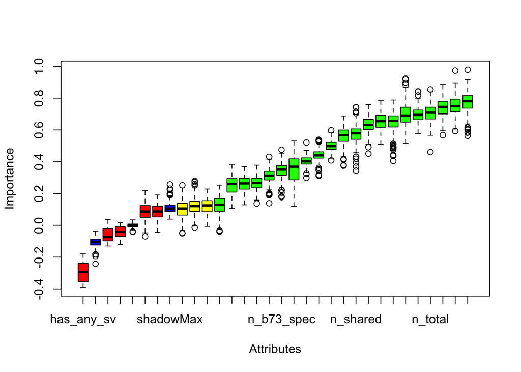

```r
# ==============================================================================
# 1. INITIALIZATION AND BORUTA RUN
# ==============================================================================

# Standardize and format data types uniformly across variables (factors/numerics)
sv_dap <- clean_dataset(sv_dap)

# Execute the Boruta wrapper feature selection using 250 iterative random forest runs.
# mcAdj = TRUE strictly applies Bonferroni corrections for high-dimensional testing.
bo_try <- Boruta(is_gxe~., data=sv_dap, mcAdj = TRUE, maxRuns = 250)

# Generate a quick base-R boxplot visualizing real features vs. shadow attribute benchmarks
plot(bo_try)
```

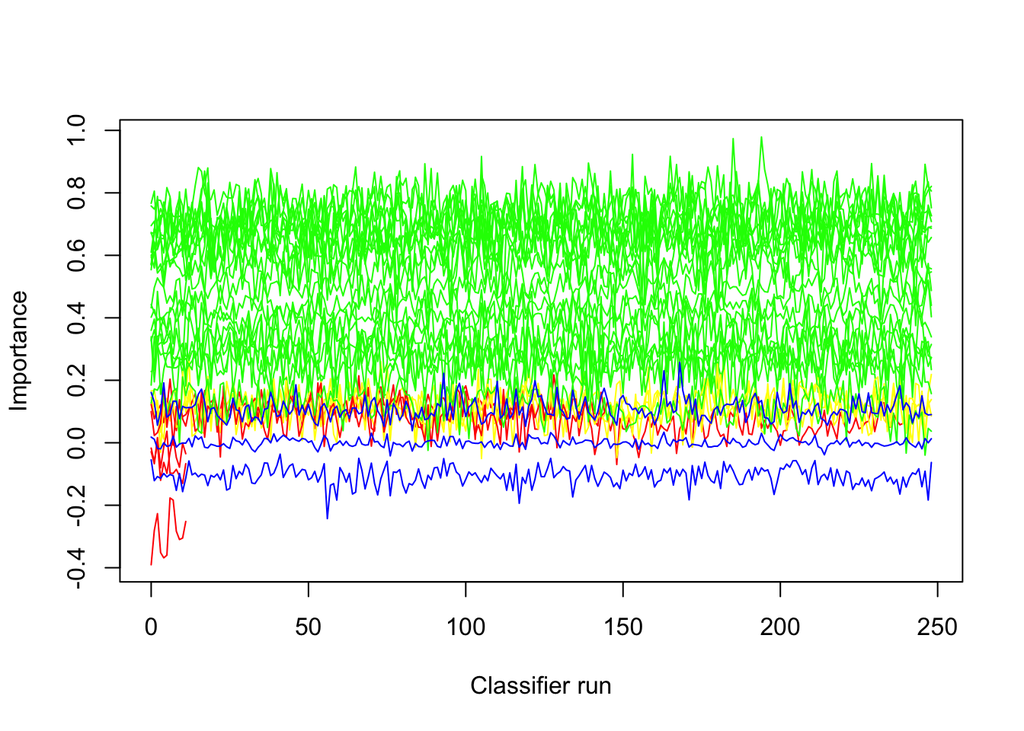

```r
# Generate a quick trace plot showing feature importance progression across the 250 runs
plotImpHistory(bo_try)
```

```r
# Render an interactive HTML data table showing ranked attribute importance metrics
DT::datatable(attStats(bo_try) |> arrange(-meanImp))
```

|  | meanImp | medianImp | minImp | maxImp | normHits | decision |
| --- | --- | --- | --- | --- | --- | --- |
| n_snp_total | 0.7724848468598955 | 0.7806694882732661 | 0.5630280974748901 | 0.9788457710008249 | 1 | Confirmed |
| n_sv_total | 0.7541821550892805 | 0.7501166395334635 | 0.5929212571998953 | 0.9736003897212422 | 1 | Confirmed |
| n_snp_no_peak | 0.7384416204961208 | 0.7450016450452294 | 0.5678393236123824 | 0.8829905971858695 | 1 | Confirmed |
| n_total | 0.7057878330470271 | 0.7086928248060357 | 0.4611263419047583 | 0.8551068987155783 | 1 | Confirmed |
| n_SNP | 0.6976107120754003 | 0.6907612632607508 | 0.5148875126825824 | 0.9232786723898572 | 1 | Confirmed |
| n_small_indel_no_peak | 0.6950504572489281 | 0.6947369654561272 | 0.5777137396218621 | 0.8432538488774676 | 1 | Confirmed |
| n_small_indel | 0.655643243532327 | 0.6554545389969997 | 0.509185587204926 | 0.783445006775024 | 1 | Confirmed |
| n_small_indel_total | 0.6500069851915029 | 0.6571536128725894 | 0.4049413273694167 | 0.788192865742021 | 1 | Confirmed |
| n_snp_shared | 0.6327904625833213 | 0.6317353573867063 | 0.4510055950868805 | 0.7598936331342636 | 1 | Confirmed |
| n_shared | 0.5733843350952282 | 0.5792858948552342 | 0.3438481128609971 | 0.74314886922321 | 1 | Confirmed |

[output cut: 19 more lines]

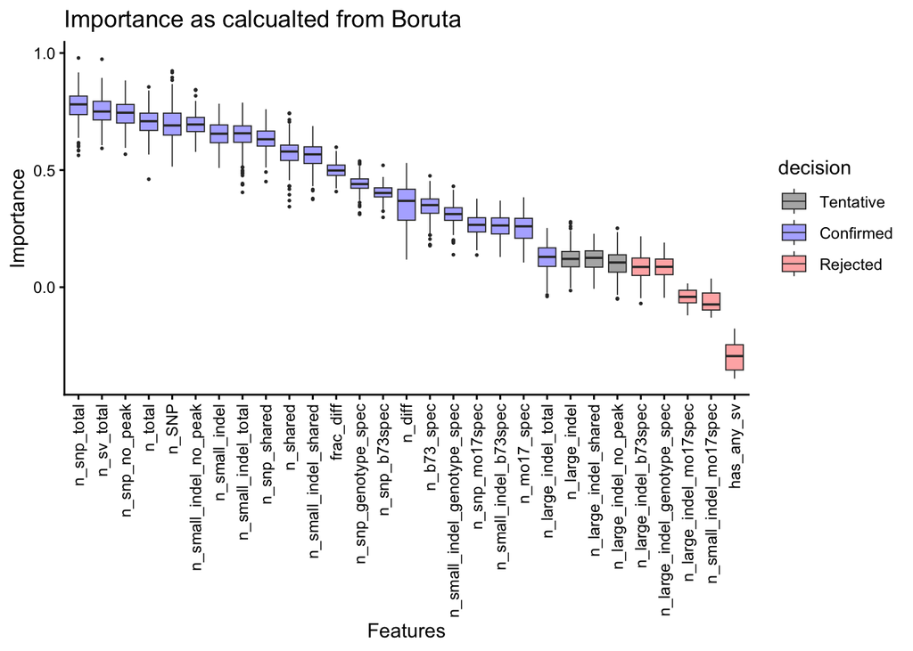

```r
# ==============================================================================
# 2. DATA EXTRACTION AND RESTRUCTURING FOR CUSTOM PLOTTING
# ==============================================================================

# Extract summary stats, rank by mean importance, and convert row names to a dedicated column
bo_tab <- attStats(bo_try) |> arrange(-meanImp) |>
  mutate(Features = rownames(attStats(bo_try) |> arrange(-meanImp)))

# Extract the full numerical history of Z-scores across all iterations into a dataframe
bo_hist <- bo_try[["ImpHistory"]] |> as.data.frame()

# Pivot the history from a wide layout into a tidy long format for ggplot compatibility
bo_hist2 <- bo_hist |> pivot_longer(cols = colnames(bo_hist), names_to = "Features", values_to = "Importance")

# Join historical run data with categorical summary decisions, omitting benchmark shadow features
bo_all <- bo_hist2 |>
  left_join(bo_tab, by = "Features") |>
  filter(!Features %in% c("shadowMax", "shadowMean", "shadowMin"))


# ==============================================================================
# 3. GEOM BOXPLOT & BARPLOT VISUALIZATIONS
# ==============================================================================

# Plot A: Vertical Boxplots tracking full Z-score distribution across iterations per feature
ggplot(bo_all, aes(x = fct_reorder(Features, -meanImp), y = Importance, fill = decision))+
         geom_boxplot(size = .3)+
  theme_classic()+
  theme(axis.text.x = element_text(angle = 90, hjust = 1, vjust = .5))+
  labs(y = "Importance", x = "Features", title = "Importance as calcualted from Boruta") +
  scale_fill_manual(values = c("#b3b3b3", "#b3b3ff", "#ffb3b3"))
```

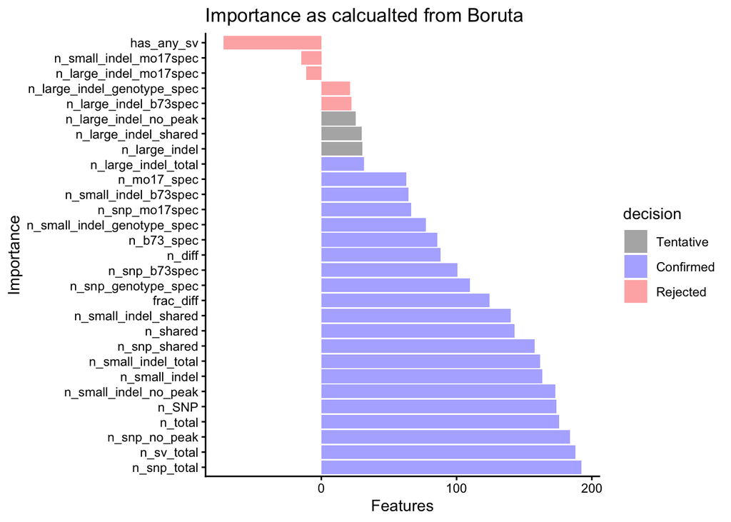

```r
# Plot B: Horizontal Bar Chart tracking static mean importance scores per feature
ggplot(bo_all, aes(y = fct_reorder(Features, -meanImp), x = meanImp, fill = decision))+
         geom_col()+
  theme_classic()+
  labs(y = "Importance", x = "Features", title = "Importance as calcualted from Boruta") +
  scale_fill_manual(values = c("#b3b3b3", "#b3b3ff", "#ffb3b3"))
```

```r
# ==============================================================================
# 4. DOWNSTREAM MACHINE LEARNING FILTERING & MODELLING
# ==============================================================================

# Isolate the subset of attributes formally marked as "Confirmed" by the Boruta algorithm
best_ones <- attStats(bo_try) |>
  filter(decision == "Confirmed")

# Subset the clean data matrix to retain only the target variable and Boruta-confirmed features
sv_dap1 <- sv_dap |>
  select(all_of(c("is_gxe", rownames(best_ones))))

# Train, cross-validate, and score the final 4 machine learning pipelines using the refined feature subset
SV_DAP_Models_Boruta <- run_all_mods(sv_dap1, Group_title = "Boruta")
```

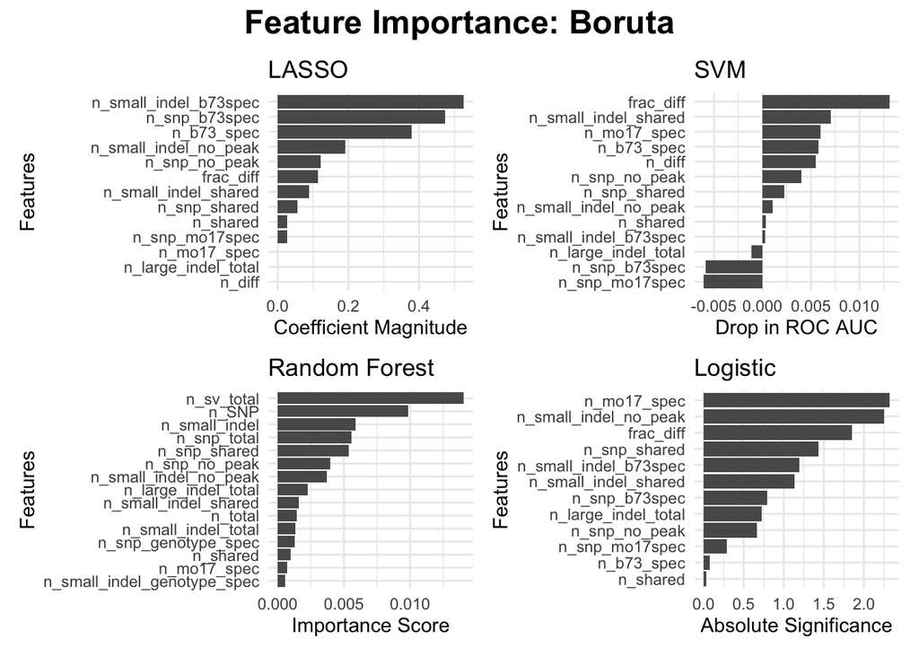

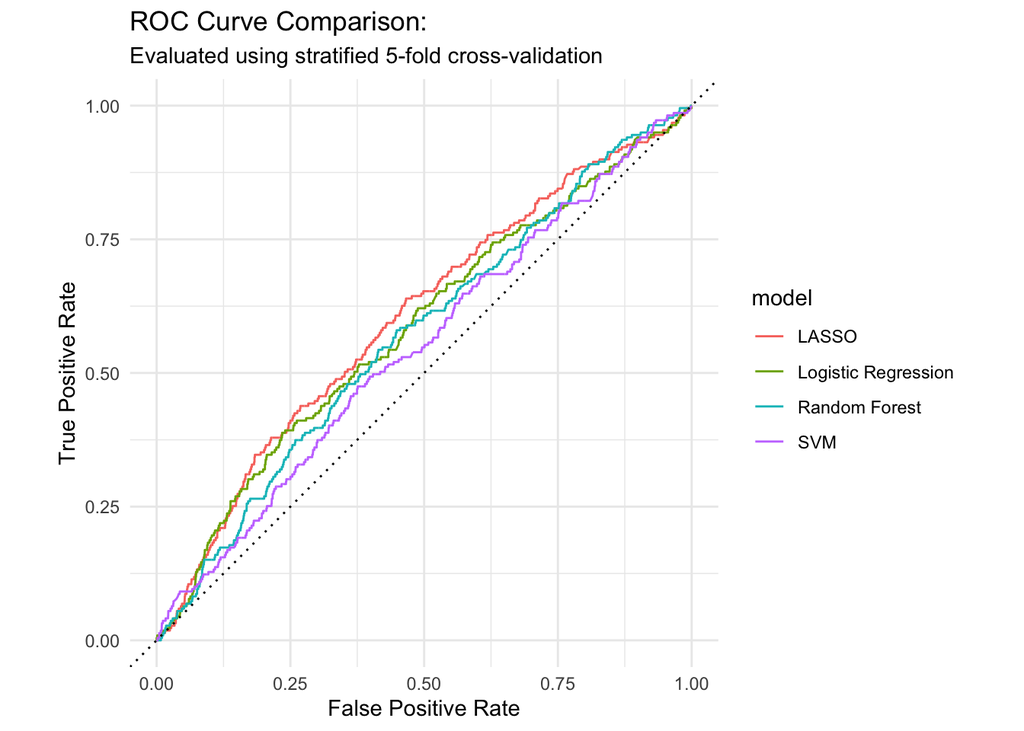

Comparative ROC AUC Performance:

| Model | Metric | Estimate |
| --- | --- | --- |
| LASSO | roc_auc | 0.6028 |
| Logistic Regression | roc_auc | 0.5834 |
| Random Forest | roc_auc | 0.5706 |
| SVM | roc_auc | 0.5469 |

Logistic: Boruta

| Term (Variable) | Estimate (Slope) | Std. Error | z-statistic | p-value |
| --- | --- | --- | --- | --- |
| (Intercept) | 4.3692 | 0.1340 | 32.6058 | < 0.0001 |
| n_small_indel | -0.0774 | 0.1162 | -0.6655 | 0.5057 |
| n_SNP | 0.0102 | 0.0964 | 0.1062 | 0.9154 |
| n_sv_total | -0.0439 | 0.0939 | -0.4672 | 0.6403 |
| n_b73_spec | -0.0489 | 0.0659 | -0.7424 | 0.4578 |
| n_shared | 0.0084 | 0.0233 | 0.3603 | 0.7186 |
| n_mo17_spec | 0.0331 | 0.0999 | 0.3310 | 0.7406 |
| n_diff | NA | NA | NA | NA |
| n_total | NA | NA | NA | NA |
| frac_diff | -0.4656 | 0.2572 | -1.8101 | 0.0703 |
| n_small_indel_b73spec | -0.3349 | 0.2653 | -1.2620 | 0.207 |
| n_small_indel_shared | 0.0073 | 0.0206 | 0.3552 | 0.7224 |
| n_small_indel_no_peak | 0.0500 | 0.0724 | 0.6914 | 0.4893 |
| n_small_indel_genotype_spec | 0.4528 | 0.2641 | 1.7143 | 0.0865 |
| n_small_indel_total | NA | NA | NA | NA |
| n_large_indel_total | -0.0800 | 0.0494 | -1.6205 | 0.1051 |
| n_snp_b73spec | -0.0007 | 0.0152 | -0.0457 | 0.9636 |
| n_snp_mo17spec | 0.0260 | 0.0417 | 0.6237 | 0.5328 |
| n_snp_shared | 0.0016 | 0.0087 | 0.1839 | 0.8541 |
| n_snp_no_peak | 0.0417 | 0.0235 | 1.7718 | 0.0764 |
| n_snp_genotype_spec | NA | NA | NA | NA |
| n_snp_total | NA | NA | NA | NA |

# Summary Plots

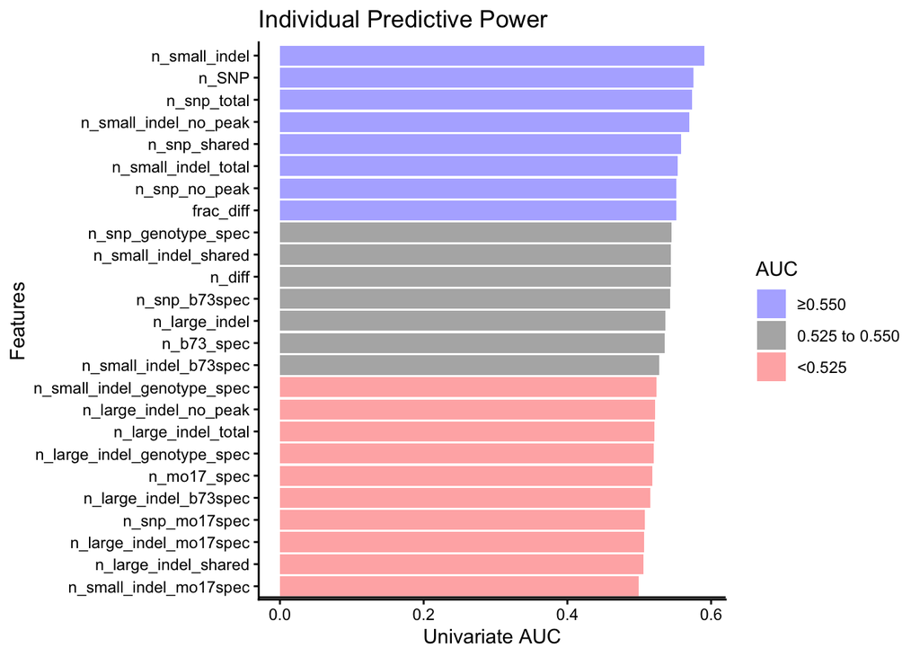

```r
# ==============================================================================
# 1. CATEGORIZE AND BIN UNIVARIATE METRICS
# ==============================================================================

# Create discrete thresholds for the Univariate Area Under the Curve (AUC) scores
predictive_signals1 <- predictive_signals |>
  mutate(
    # Simplify the data source origins into descriptive category titles
    Type = if_else(Source == "SV Only", "Structural Variant", "DAP-seq"),

    # Bin continuous AUC values into 3 distinct, publication-ready tiers
    AUC = case_when(
      Univariate_AUC >= 0.550 ~ "≥0.550",
      Univariate_AUC < 0.550 & Univariate_AUC >= 0.525 ~ "0.525 to 0.550",
      TRUE ~ "<0.525"
    ),

    # Standardize the feature name variable handle for downstream merging
    Features = Variable
  )


# ==============================================================================
# 2. COMBINE UNIVARIATE DATA WITH BORUTA STATS
# ==============================================================================

# Merge the univariate screening dataframe with the Boruta importance summaries
predictive_signals2 <- predictive_signals1 |>
  full_join(bo_tab, by = "Features") |>

  # Keep only informative variables and drop non-specific aggregate features
  filter(
    Mutual_Information > 0,
    !Features %in% c("n_total", "n_shared")
  ) |>

  # Duplicate the Boruta selection categorical column into a cleanly labeled header
  mutate("Boruta Decision" = decision)


# ==============================================================================
# 3. PLOT 1: STANDARD GGPLOT HORIZONTAL BAR CHART (UNIVARIATE POWER)
# ==============================================================================

# Plot features ordered by individual AUC performance, colored by discrete thresholds
ggplot(predictive_signals2, aes( y = fct_reorder(Variable, Univariate_AUC), x = Univariate_AUC, fill = fct_relevel(AUC,c("≥0.550", "0.525 to 0.550", "<0.525")))) +
         geom_col()+
  scale_fill_manual(values = c("#b3b3ff", "#b3b3b3", "#ffb3b3"))+
  theme_classic()+
  labs(x = "Univariate AUC", y = "Features", title = "Individual Predictive Power", fill = "AUC")+
  geom_hline(yintercept = 0.5) # Reference line mapping a zero-predictive-value threshold
```

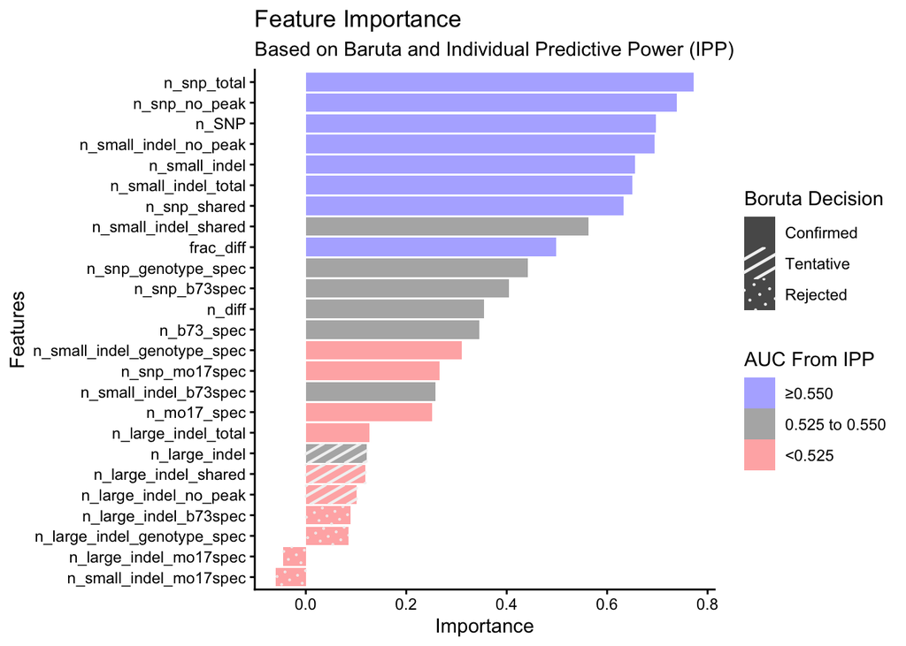

```r
# ==============================================================================
# 4. PLOT 2: GGPATTERN GEOM (DUAL ENCODING IMPORTANCE & SELECTION STATUS)
# ==============================================================================

# Construct a high-density publication figure mapping mean importance scores (X-axis),
# individual AUC categories (colors), and Boruta framework decisions (shading patterns)
p1 <- ggplot(predictive_signals2, aes(
    y = fct_reorder(Features, meanImp),
    x = meanImp,
    fill = fct_relevel(AUC, c("≥0.550", "0.525 to 0.550", "<0.525")),
    pattern = fct_relevel(decision, c("Confirmed", "Tentative", "Rejected"))
  )) +
  geom_col_pattern(
    pattern_color = "grey95",       # Color tint of the fill pattern overlays
    pattern_fill = "grey95",
    pattern_spacing = 0.02,         # Distance layout metrics separating lines/dots
    pattern_density = 0.1
  ) +
  theme_classic() +
  labs(
    x = "Importance",
    y = "Features",
    title = "Feature Importance",
    subtitle = "Based on Baruta and Individual Predictive Power (IPP)", # Note: "Baruta" typo here in title string
    fill = "AUC From IPP",
    pattern = "Boruta Decision"
  ) +
  scale_fill_manual(values = c("#b3b3ff", "#b3b3b3", "#ffb3b3")) +
  scale_pattern_manual(values = c("none", "stripe", "circle")) + # Maps unique overlays to selection states
  guides(fill = guide_legend(override.aes = list(pattern = "none"))) # Suppresses pattern clutter in the color legend

p1
```

```r
# Export the customized dual-encoded figure to a local high-resolution file
ggsave("../../../bmo_ase_gxe_nogit/Features_Boruta_AUC.png", p1)
```

# Summary Tables

```r
gxe_features_ref <- tibble(
  `Feature Name` = c(
    "n_snp_total",
    "n_snp_no_peak",
    "n_SNP",
    "n_small_indel_no_peak",
    "n_small_indel",
    "n_small_indel_total",
    "n_snp_shared",
    "frac_diff"
  ),
  `Extended Feature Name` = c(
    "Total Promoter SNPs (DAP Consolidated)",
    "Promoter SNPs with No Peak Overlap",
    "Total Baseline Promoter SNPs",
    "Promoter Small Indels with No Peak Overlap",
    "Total Baseline Promoter Small Indels",
    "Total Promoter Small Indels (DAP Consolidated)",
    "Promoter SNPs Overlapping Shared Peaks",
    "Fraction of Genotype-Specific DAP Peaks"
  ),
  `Data Type` = c(
    "DAP_seq",
    "DAP_seq",
    "Structural Variants",
    "DAP_seq",
    "Structural Variants",
    "DAP_seq",
    "DAP_seq",
    "DAP_seq"
  ),
  `Boruta Importance` = c(
    0.770,
    0.740,
    0.703,
    0.689,
    0.647,
    0.646,
    0.635,
    0.499
  ),
  `Univariate AUC` = c(
    0.573,
    0.551,
    0.575,
    0.569,
    0.591,
    0.554,
    0.558,
    0.551
  ),
  `Mutual Information` = c(
    0.0006,
    0.0002,
    0.0002,
    0.0002,
    0.0010,
    0.0003,
    0.0004,
    0.0011
  ),
  `Biological Description` = c(
    "The total count of Single Nucleotide Polymorphisms (SNPs) located within the gene's promoter region (+/-500bp from the Transcription Start Site), mapped within the DAP-seq consolidated framework.",
    "The count of promoter SNPs that do not physically overlap with any documented DAP-seq transcription factor binding peak, representing variants in non-binding promoter regions.",
    "The total baseline count of B73/Mo17 SNPs detected within the gene's promoter region, capturing sequence divergence between the parent genotypes.",
    "The count of small insertions or deletions (< 50 bp) in the promoter region that do not overlap with any DAP-seq transcription factor binding peak.",
    "The total baseline count of small insertions or deletions (< 50 bp) detected within the gene's promoter region.",
    "The total count of small insertions or deletions (< 50 bp) in the promoter region, tracked within the consolidated DAP-seq overlap architecture.",
    "The count of promoter SNPs that physically overlap with shared DAP-seq peaks (transcription factor binding sites present in both the B73 and Mo17 genotypes).",
    "The proportion of total transcription factor binding peaks in the promoter region that are genotype-specific (either B73-only or Mo17-only), serving as an index of localized regulatory divergence."
  )
)

# Preview the complete table
write_tsv(gxe_features_ref, file = "../../../bmo_ase_gxe_nogit/GxE_feature_importance.tsv", quote = "all")

pander(gxe_features_ref)
```

| Feature Name | Extended Feature Name | Data Type | Boruta Importance | Univariate AUC | Mutual Information | Biological Description |
| --- | --- | --- | --- | --- | --- | --- |
| n_snp_total | Total Promoter SNPs (DAP Consolidated) | DAP_seq | 0.77 | 0.573 | 6e-04 | The total count of Single Nucleotide Polymorphisms (SNPs) located within the gene’s promoter region (+/-500bp from the Transcription Start Site), mapped within the DAP-seq consolidated framework. |
| n_snp_no_peak | Promoter SNPs with No Peak Overlap | DAP_seq | 0.74 | 0.551 | 2e-04 | The count of promoter SNPs that do not physically overlap with any documented DAP-seq transcription factor binding peak, representing variants in non-binding promoter regions. |
| n_SNP | Total Baseline Promoter SNPs | Structural Variants | 0.703 | 0.575 | 2e-04 | The total baseline count of B73/Mo17 SNPs detected within the gene’s promoter region, capturing sequence divergence between the parent genotypes. |
| n_small_indel_no_peak | Promoter Small Indels with No Peak Overlap | DAP_seq | 0.689 | 0.569 | 2e-04 | The count of small insertions or deletions (< 50 bp) in the promoter region that do not overlap with any DAP-seq transcription factor binding peak. |
| n_small_indel | Total Baseline Promoter Small Indels | Structural Variants | 0.647 | 0.591 | 0.001 | The total baseline count of small insertions or deletions (< 50 bp) detected within the gene’s promoter region. |
| n_small_indel_total | Total Promoter Small Indels (DAP Consolidated) | DAP_seq | 0.646 | 0.554 | 3e-04 | The total count of small insertions or deletions (< 50 bp) in the promoter region, tracked within the consolidated DAP-seq overlap architecture. |
| n_snp_shared | Promoter SNPs Overlapping Shared Peaks | DAP_seq | 0.635 | 0.558 | 4e-04 | The count of promoter SNPs that physically overlap with shared DAP-seq peaks (transcription factor binding sites present in both the B73 and Mo17 genotypes). |
| frac_diff | Fraction of Genotype-Specific DAP Peaks | DAP_seq | 0.499 | 0.551 | 0.0011 | The proportion of total transcription factor binding peaks in the promoter region that are genotype-specific (either B73-only or Mo17-only), serving as an index of localized regulatory divergence. |

```r
# Create the consolidated data frame with all three conditions
model_comparison <- tibble(
  Model = c("LASSO", "Logistic_Regression", "Random_Forest", "SVM"),
  All_Features_AUC = c(0.5967, 0.5774, 0.5708, 0.5438),
  Boruta_Confirmed_Features_AUC = c(0.6028, 0.5834, 0.5706, 0.5469),
  Univariate_Filtered_Features_AUC = c(0.5924, 0.5825, 0.5451, 0.5672)
)

write_tsv(model_comparison, file = "../../../bmo_ase_gxe_nogit/GxE_prediction_models_AUC.tsv")

pander(model_comparison)
```

| Model | All_Features_AUC | Boruta_Confirmed_Features_AUC | Univariate_Filtered_Features_AUC |
| --- | --- | --- | --- |
| LASSO | 0.5967 | 0.6028 | 0.5924 |
| Logistic_Regression | 0.5774 | 0.5834 | 0.5825 |
| Random_Forest | 0.5708 | 0.5706 | 0.5451 |
| SVM | 0.5438 | 0.5469 | 0.5672 |

R version 4.5.2 (2025-10-31) Platform: aarch64-apple-darwin20 Running under: macOS Tahoe 26.4

Matrix products: default BLAS: /System/Library/Frameworks/Accelerate.framework/Versions/A/Frameworks/vecLib.framework/Versions/A/libBLAS.dylib LAPACK: /Library/Frameworks/R.framework/Versions/4.5-arm64/Resources/lib/libRlapack.dylib; LAPACK version 3.12.1

locale: [1] en_US.UTF-8/en_US.UTF-8/en_US.UTF-8/C/en_US.UTF-8/en_US.UTF-8

time zone: America/New_York tzcode source: internal

attached base packages: [1] parallel stats graphics grDevices utils datasets methods  
[8] base

other attached packages: [1] ggpattern_1.3.1 Boruta_10.0.0 themis_1.0.3 kableExtra_1.4.0  
[5] knitr_1.51 doParallel_1.0.17 iterators_1.0.14 foreach_1.5.2  
[9] vip_0.4.6 glmnet_5.0 Matrix_1.7-5 yardstick_1.4.0  
[13] workflowsets_1.1.1 workflows_1.3.0 tune_2.1.0 tailor_0.1.0  
[17] rsample_1.3.2 recipes_1.3.2 parsnip_1.6.0 modeldata_1.5.1  
[21] infer_1.1.0 dials_1.4.3 scales_1.4.0 broom_1.0.12  
[25] tidymodels_1.5.0 DT_0.34.0 pander_0.6.6 patchwork_1.3.2  
[29] lubridate_1.9.5 forcats_1.0.1 stringr_1.6.0 dplyr_1.2.1  
[33] purrr_1.2.2 readr_2.2.0 tidyr_1.3.2 tibble_3.3.1  
[37] ggplot2_4.0.3 tidyverse_2.0.0

loaded via a namespace (and not attached): [1] DBI_1.3.0 pROC_1.19.0.1 rlang_1.2.0  
[4] magrittr_2.0.5 furrr_0.4.0 otel_0.2.0  
[7] e1071_1.7-17 compiler_4.5.2 systemfonts_1.3.2  
[10] vctrs_0.7.3 crayon_1.5.3 pkgconfig_2.0.3  
[13] shape_1.4.6.1 fastmap_1.2.0 backports_1.5.1  
[16] labeling_0.4.3 rmarkdown_2.31 prodlim_2026.03.11 [19] tzdb_0.5.0 ragg_1.5.2 bit_4.6.0  
[22] xfun_0.57 cachem_1.1.0 jsonlite_2.0.0  
[25] R6_2.6.1 bslib_0.10.0 stringi_1.8.7  
[28] RColorBrewer_1.1-3 ranger_0.18.0 parallelly_1.47.0  
[31] rpart_4.1.27 jquerylib_0.1.4 Rcpp_1.1.1-1  
[34] future.apply_1.20.2 splines_4.5.2 nnet_7.3-20  
[37] timechange_0.4.0 tidyselect_1.2.1 rstudioapi_0.18.0  
[40] dichromat_2.0-0.1 yaml_2.3.12 timeDate_4052.112  
[43] codetools_0.2-20 listenv_0.10.1 lattice_0.22-9  
[46] withr_3.0.2 S7_0.2.1-1 evaluate_1.0.5  
[49] sf_1.1-0 future_1.70.0 survival_3.8-6  
[52] units_1.0-1 proxy_0.4-29 xml2_1.5.2  
[55] kernlab_0.9-33 pillar_1.11.1 KernSmooth_2.23-26 [58] generics_0.1.4 vroom_1.7.1 hms_1.1.4  
[61] globals_0.19.1 class_7.3-23 glue_1.8.1  
[64] ROSE_0.0-4 tools_4.5.2 data.table_1.18.2.1 [67] gridpattern_1.3.1 gower_1.0.2 fru_0.0.7  
[70] grid_4.5.2 crosstalk_1.2.2 ipred_0.9-15  
[73] cli_3.6.6 DiceDesign_1.10 textshaping_1.0.5  
[76] viridisLite_0.4.3 svglite_2.2.2 lava_1.9.0  
[79] gtable_0.3.6 sass_0.4.10 digest_0.6.39  
[82] classInt_0.4-11 htmlwidgets_1.6.4 farver_2.1.2  
[85] memoise_2.0.1 htmltools_0.5.9 lifecycle_1.0.5  
[88] hardhat_1.4.3 sparsevctrs_0.3.6 bit64_4.6.0-1  
[91] MASS_7.3-65